# Porter_NNRegression

## Porter - NNRegression

### Importing Libraries

When an order is placed, predict how many minutes it will take to deliver the order to the customer. Accurate delivery-time prediction can help a food-delivery platform improve ETA estimates, customer experience, delivery-partner allocation, and operational planning.

```python
# libraries to analyze data
import numpy as np
import pandas as pd

# libraries to visualize data
import matplotlib.pyplot as plt
import seaborn as sns

from sklearn.neighbors import LocalOutlierFactor

from sklearn.impute import KNNImputer

from sklearn.preprocessing import OneHotEncoder
from sklearn.model_selection import train_test_split
from sklearn.preprocessing import StandardScaler, MinMaxScaler
from statsmodels.stats.outliers_influence import variance_inflation_factor
from tensorflow.keras.models import Sequential
from tensorflow.keras.layers import Dense, Activation, LeakyReLU, Dropout, BatchNormalization
from tensorflow.keras.optimizers import Adam, RMSprop
from sklearn.metrics import mean_squared_error
```

### Upload dataset

```python
df = pd.read_csv('Porter_data_2.csv')
df
```

|  | market_id | created_at | actual_delivery_time | store_primary_category | order_protocol | total_items | subtotal | num_distinct_items | min_item_price | max_item_price | total_onshift_dashers | total_busy_dashers | total_outstanding_orders | estimated_store_to_consumer_driving_duration |
| --- | --- | --- | --- | --- | --- | --- | --- | --- | --- | --- | --- | --- | --- | --- |
| 0 | 1 | 2/6/2015 22:24 | 2/6/2015 23:11 | 4 | 1 | 4 | 3441 | 4 | 557 | 1239 | 33 | 14 | 21 | 861 |
| 1 | 2 | 2/10/2015 21:49 | 2/10/2015 22:33 | 46 | 2 | 1 | 1900 | 1 | 1400 | 1400 | 1 | 2 | 2 | 690 |
| 2 | 2 | 2/16/2015 0:11 | 2/16/2015 1:06 | 36 | 3 | 4 | 4771 | 3 | 820 | 1604 | 8 | 6 | 18 | 289 |
| 3 | 1 | 2/12/2015 3:36 | 2/12/2015 4:35 | 38 | 1 | 1 | 1525 | 1 | 1525 | 1525 | 5 | 6 | 8 | 795 |
| 4 | 1 | 1/27/2015 2:12 | 1/27/2015 2:58 | 38 | 1 | 2 | 3620 | 2 | 1425 | 2195 | 5 | 5 | 7 | 205 |
| ... | ... | ... | ... | ... | ... | ... | ... | ... | ... | ... | ... | ... | ... | ... |
| 175772 | 1 | 2/17/2015 0:19 | 2/17/2015 1:02 | 28 | 4 | 3 | 1389 | 3 | 345 | 649 | 17 | 17 | 23 | 331 |
| 175773 | 1 | 2/13/2015 0:01 | 2/13/2015 1:03 | 28 | 4 | 6 | 3010 | 4 | 405 | 825 | 12 | 11 | 14 | 915 |
| 175774 | 1 | 1/24/2015 4:46 | 1/24/2015 5:32 | 28 | 4 | 5 | 1836 | 3 | 300 | 399 | 39 | 41 | 40 | 795 |
| 175775 | 1 | 2/1/2015 18:18 | 2/1/2015 19:03 | 58 | 1 | 1 | 1175 | 1 | 535 | 535 | 7 | 7 | 12 | 384 |
| 175776 | 1 | 2/8/2015 19:24 | 2/8/2015 20:01 | 58 | 1 | 4 | 2605 | 4 | 425 | 750 | 20 | 20 | 23 | 134 |

175777 rows × 14 columns

```python
df.info()
```

```
<class 'pandas.core.frame.DataFrame'>
RangeIndex: 175777 entries, 0 to 175776
Data columns (total 14 columns):
 #   Column                                        Non-Null Count   Dtype
---  ------                                        --------------   -----
 0   market_id                                     175777 non-null  int64
 1   created_at                                    175777 non-null  object
 2   actual_delivery_time                          175777 non-null  object
 3   store_primary_category                        175777 non-null  int64
 4   order_protocol                                175777 non-null  int64
 5   total_items                                   175777 non-null  int64
 6   subtotal                                      175777 non-null  int64
 7   num_distinct_items                            175777 non-null  int64
 8   min_item_price                                175777 non-null  int64
 9   max_item_price                                175777 non-null  int64
 10  total_onshift_dashers                         175777 non-null  int64
 11  total_busy_dashers                            175777 non-null  int64
 12  total_outstanding_orders                      175777 non-null  int64
 13  estimated_store_to_consumer_driving_duration  175777 non-null  int64
dtypes: int64(12), object(2)
memory usage: 18.8+ MB
```

```python
df.shape
```

```
(175777, 14)
```

```python
df.isna().sum()
```

```
market_id                                       0
created_at                                      0
actual_delivery_time                            0
store_primary_category                          0
order_protocol                                  0
total_items                                     0
subtotal                                        0
num_distinct_items                              0
min_item_price                                  0
max_item_price                                  0
total_onshift_dashers                           0
total_busy_dashers                              0
total_outstanding_orders                        0
estimated_store_to_consumer_driving_duration    0
dtype: int64
```

```python
df.nunique()
```

```
market_id                                           6
created_at                                      23362
actual_delivery_time                            23420
store_primary_category                             73
order_protocol                                      7
total_items                                        54
subtotal                                         8182
num_distinct_items                                 20
min_item_price                                   2251
max_item_price                                   2585
total_onshift_dashers                             172
total_busy_dashers                                158
total_outstanding_orders                          281
estimated_store_to_consumer_driving_duration     1318
dtype: int64
```

```python
df.duplicated().value_counts()
```

```
False    175776
True          1
Name: count, dtype: int64
```

```python
df.describe()
```

|  | market_id | store_primary_category | order_protocol | total_items | subtotal | num_distinct_items | min_item_price | max_item_price | total_onshift_dashers | total_busy_dashers | total_outstanding_orders | estimated_store_to_consumer_driving_duration |
| --- | --- | --- | --- | --- | --- | --- | --- | --- | --- | --- | --- | --- |
| count | 175777.000000 | 175777.000000 | 175777.000000 | 175777.000000 | 175777.000000 | 175777.000000 | 175777.000000 | 175777.000000 | 175777.000000 | 175777.000000 | 175777.000000 | 175777.000000 |
| mean | 2.743726 | 35.887949 | 2.911752 | 3.204976 | 2697.111147 | 2.675060 | 684.965433 | 1160.158616 | 44.918664 | 41.861381 | 58.230115 | 546.077240 |
| std | 1.330963 | 20.728254 | 1.513128 | 2.674055 | 1828.554893 | 1.625681 | 519.882924 | 560.828571 | 34.544724 | 32.168505 | 52.731043 | 218.717798 |
| min | 1.000000 | 0.000000 | 1.000000 | 1.000000 | 0.000000 | 1.000000 | -86.000000 | 0.000000 | -4.000000 | -5.000000 | -6.000000 | 0.000000 |
| 25% | 2.000000 | 18.000000 | 1.000000 | 2.000000 | 1412.000000 | 1.000000 | 299.000000 | 799.000000 | 17.000000 | 15.000000 | 17.000000 | 384.000000 |
| 50% | 2.000000 | 38.000000 | 3.000000 | 3.000000 | 2224.000000 | 2.000000 | 595.000000 | 1095.000000 | 37.000000 | 35.000000 | 41.000000 | 544.000000 |
| 75% | 4.000000 | 55.000000 | 4.000000 | 4.000000 | 3410.000000 | 3.000000 | 942.000000 | 1395.000000 | 66.000000 | 63.000000 | 85.000000 | 703.000000 |
| max | 6.000000 | 72.000000 | 7.000000 | 411.000000 | 26800.000000 | 20.000000 | 14700.000000 | 14700.000000 | 171.000000 | 154.000000 | 285.000000 | 2088.000000 |

```python
df.describe(include='object')
```

|  | created_at | actual_delivery_time |
| --- | --- | --- |
| count | 175777 | 175777 |
| unique | 23362 | 23420 |
| top | 2/11/2015 19:51 | 2/14/2015 3:57 |
| freq | 48 | 42 |

```python
min(df['created_at']), max(df['created_at'])
```

```
('1/21/2015 15:22', '2/9/2015 6:00')
```

```python
## Removing 1 duplicate value

df = df.drop_duplicates().reset_index(drop=True)

print(df.shape)
print(df.duplicated().sum())
```

```
(175776, 14)
0
```

```python
# 'created_at' and 'actual_delivery_time' converted to of type datetime
df[['created_at', 'actual_delivery_time']] = df[['created_at', 'actual_delivery_time']].astype('datetime64[ns]')
df[['market_id', 'order_protocol', 'num_distinct_items']] = df[['market_id', 'order_protocol', 'num_distinct_items']].astype('category')
```

```python
df['created_hour']=df['created_at'].dt.hour # created - created_hour
df['created_day']=df['created_at'].dt.dayofweek # created - created_day
df['delivery_time_mins'] = round((df['actual_delivery_time'] - df['created_at'])/pd.Timedelta(minutes=1), 0) # created - delivery_time_mins
df.drop(columns=['created_at', 'actual_delivery_time'], inplace=True) # dropping off - created_at and actual_delivery_time
df.info()
```

```
<class 'pandas.core.frame.DataFrame'>
RangeIndex: 175776 entries, 0 to 175775
Data columns (total 15 columns):
 #   Column                                        Non-Null Count   Dtype
---  ------                                        --------------   -----
 0   market_id                                     175776 non-null  category
 1   store_primary_category                        175776 non-null  int64
 2   order_protocol                                175776 non-null  category
 3   total_items                                   175776 non-null  int64
 4   subtotal                                      175776 non-null  int64
 5   num_distinct_items                            175776 non-null  category
 6   min_item_price                                175776 non-null  int64
 7   max_item_price                                175776 non-null  int64
 8   total_onshift_dashers                         175776 non-null  int64
 9   total_busy_dashers                            175776 non-null  int64
 10  total_outstanding_orders                      175776 non-null  int64
 11  estimated_store_to_consumer_driving_duration  175776 non-null  int64
 12  created_hour                                  175776 non-null  int32
 13  created_day                                   175776 non-null  int32
 14  delivery_time_mins                            175776 non-null  float64
dtypes: category(3), float64(1), int32(2), int64(9)
memory usage: 15.3 MB
```

```python
df.describe()
```

|  | store_primary_category | total_items | subtotal | min_item_price | max_item_price | total_onshift_dashers | total_busy_dashers | total_outstanding_orders | estimated_store_to_consumer_driving_duration | created_hour | created_day | delivery_time_mins |
| --- | --- | --- | --- | --- | --- | --- | --- | --- | --- | --- | --- | --- |
| count | 175776.000000 | 175776.000000 | 175776.000000 | 175776.000000 | 175776.000000 | 175776.000000 | 175776.000000 | 175776.000000 | 175776.000000 | 175776.000000 | 175776.000000 | 175776.000000 |
| mean | 35.888017 | 3.204988 | 2697.122224 | 684.967060 | 1160.162946 | 44.918459 | 41.861159 | 58.229525 | 546.076905 | 8.473483 | 3.222311 | 46.202872 |
| std | 20.728294 | 2.674058 | 1828.554196 | 519.883955 | 560.827228 | 34.544715 | 32.168461 | 52.730612 | 218.718375 | 8.676815 | 2.043865 | 9.327263 |
| min | 0.000000 | 1.000000 | 0.000000 | -86.000000 | 0.000000 | -4.000000 | -5.000000 | -6.000000 | 0.000000 | 0.000000 | 0.000000 | 32.000000 |
| 25% | 18.000000 | 2.000000 | 1412.000000 | 299.000000 | 799.000000 | 17.000000 | 15.000000 | 17.000000 | 383.750000 | 2.000000 | 1.000000 | 39.000000 |
| 50% | 38.000000 | 3.000000 | 2224.000000 | 595.000000 | 1095.000000 | 37.000000 | 35.000000 | 41.000000 | 544.000000 | 3.000000 | 3.000000 | 45.000000 |
| 75% | 55.000000 | 4.000000 | 3410.000000 | 942.000000 | 1395.000000 | 66.000000 | 63.000000 | 85.000000 | 703.000000 | 19.000000 | 5.000000 | 52.000000 |
| max | 72.000000 | 411.000000 | 26800.000000 | 14700.000000 | 14700.000000 | 171.000000 | 154.000000 | 285.000000 | 2088.000000 | 23.000000 | 6.000000 | 110.000000 |

## Exploratory Data Analysis

#### 1. Univariate Analysis

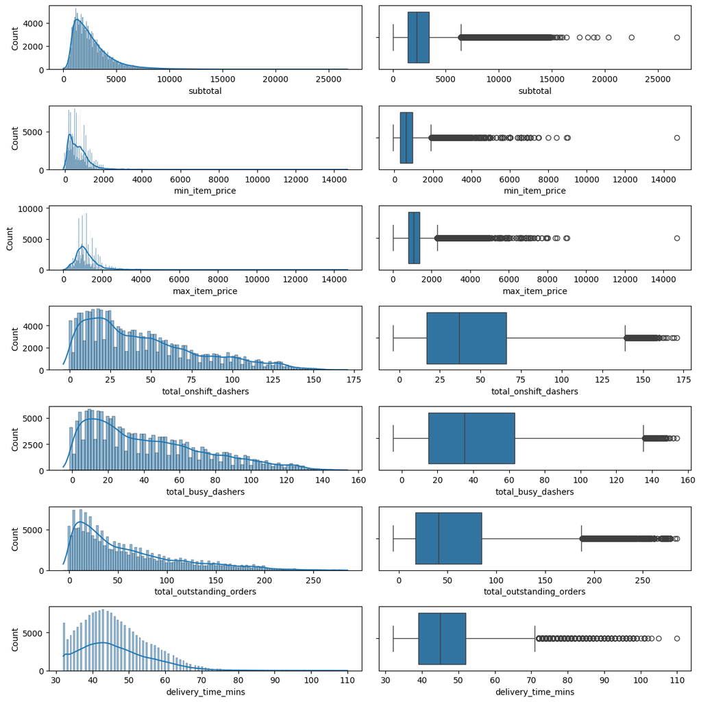

```python
fig, axes = plt.subplots(nrows=7, ncols=2, figsize = (12, 12))
sns.histplot(data=df, x = "subtotal", kde=True, ax=axes[0,0])
sns.boxplot(data=df, x = "subtotal", ax=axes[0,1])
sns.histplot(data=df, x = "min_item_price", kde=True, ax=axes[1,0])
sns.boxplot(data=df, x = "min_item_price", ax=axes[1,1])
sns.histplot(data=df, x = "max_item_price", kde=True, ax=axes[2,0])
sns.boxplot(data=df, x = "max_item_price", ax=axes[2,1])
sns.histplot(data=df, x = "total_onshift_dashers", kde=True, ax=axes[3,0])
sns.boxplot(data=df, x = "total_onshift_dashers", ax=axes[3,1])
sns.histplot(data=df, x = "total_busy_dashers", kde=True, ax=axes[4,0])
sns.boxplot(data=df, x = "total_busy_dashers", ax=axes[4,1])
sns.histplot(data=df, x = "total_outstanding_orders", kde=True, ax=axes[5,0])
sns.boxplot(data=df, x = "total_outstanding_orders", ax=axes[5,1])
sns.histplot(data=df, x = "delivery_time_mins", kde=True, ax=axes[6,0])
sns.boxplot(data=df, x = "delivery_time_mins", ax=axes[6,1])
plt.tight_layout()
plt.show()
```

Majority of the subtotal is in the range of 0 to 5000 Majority of min_item_price and max_item_price are in the range of 0 to 2000 total_onshift_partners, total_busy_dashers, total_outstanding_dashers and delivery_time_mins seem to follow similar kind of distribution - right skewed The boxplot clearly shows the presence of outliers in subtotal, min_item_price, max_item_price and delivery_time_mins

### Categorical variables

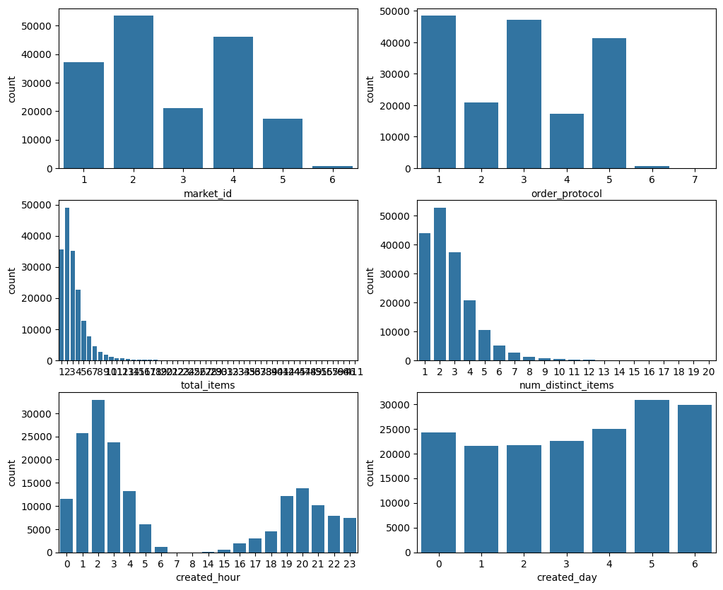

```python
fig, axes = plt.subplots(3,2,figsize=(12,10))
sns.countplot(ax=axes[0,0], data=df, x='market_id')
sns.countplot(ax=axes[0,1], data=df, x='order_protocol')
sns.countplot(ax=axes[1,0], data=df, x='total_items')
sns.countplot(ax=axes[1,1], data=df, x='num_distinct_items')
sns.countplot(ax=axes[2,0], data=df, x='created_hour')
sns.countplot(ax=axes[2,1], data=df, x='created_day')
plt.show()
```

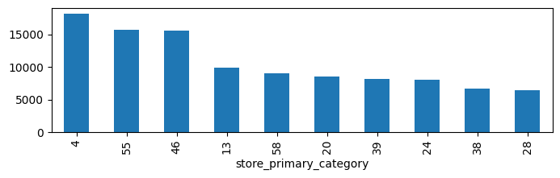

```python
df['store_primary_category'].value_counts()[:10].plot(kind='bar', figsize = (8, 2))
plt.show()
```

market_id 2 is the major contributor Majority of order placement are through protocal 1 and 3 Majority of orders have 2 num_distinct_items as well as 2 total_items Majority of the orders are placed at around 2AM and on weekends Majority of orders delivered are from restaurant 4

```python
mask = (df['min_item_price'] >= 0) & (df['max_item_price'] >= 0) & (df['total_onshift_dashers'] >= 0) & (df['total_busy_dashers'] >= 0) & (df['total_outstanding_orders'] >= 0)
df = df[mask]
```

Right-skewed distributions and outliers, particularly in order value, item price, and delivery time.

## Handling Outlier

```python
df['store_primary_category']=df['store_primary_category'].astype('category').cat.codes
```

```python
for col in ['subtotal', 'min_item_price', 'max_item_price', 'delivery_time_mins', 'total_items']:
    lower_bound = df[col].quantile(0.01)
    upper_bound = df[col].quantile(0.99)
    df = df[(df[col] >= lower_bound) & (df[col] <= upper_bound)]
```

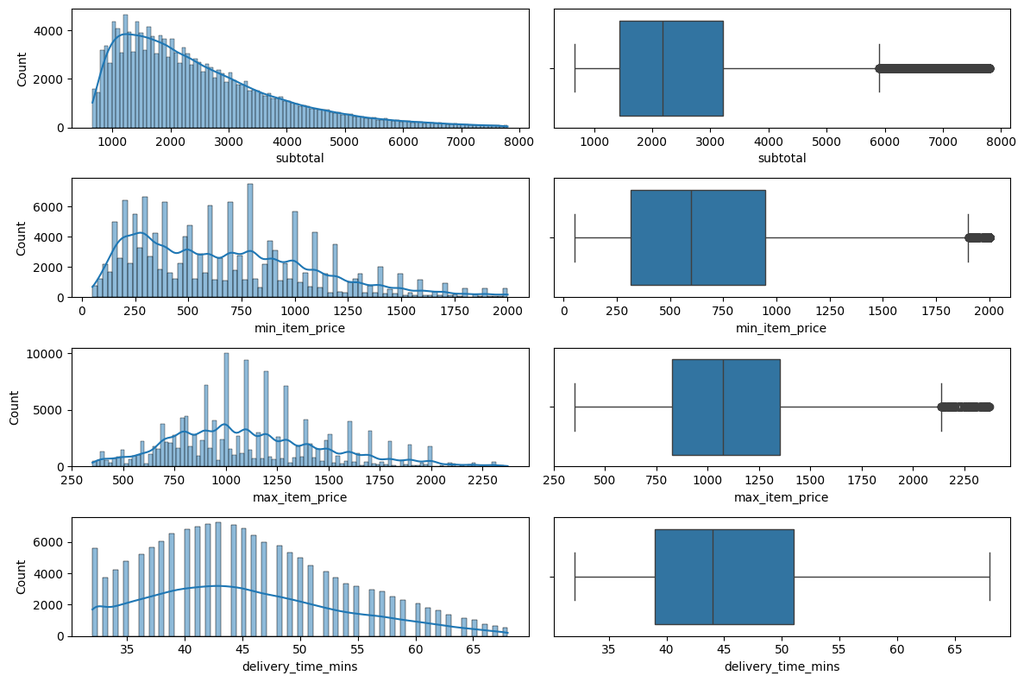

```python
fig, axes = plt.subplots(nrows=4, ncols=2, figsize = (12, 8))
sns.histplot(data=df, x = "subtotal", kde=True, ax=axes[0,0])
sns.boxplot(data=df, x = "subtotal", ax=axes[0,1])
sns.histplot(data=df, x = "min_item_price", kde=True, ax=axes[1,0])
sns.boxplot(data=df, x = "min_item_price", ax=axes[1,1])
sns.histplot(data=df, x = "max_item_price", kde=True, ax=axes[2,0])
sns.boxplot(data=df, x = "max_item_price", ax=axes[2,1])
sns.histplot(data=df, x = "delivery_time_mins", kde=True, ax=axes[3,0])
sns.boxplot(data=df, x = "delivery_time_mins", ax=axes[3,1])
plt.tight_layout()
plt.show()
```

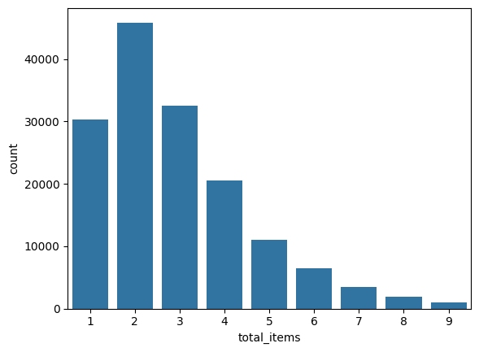

```python
sns.countplot(data=df, x='total_items')
plt.show()
```

The distribution of data looks better after removing outliers. Most of the delivery is done in 40mins

#### Bivariate Analysis

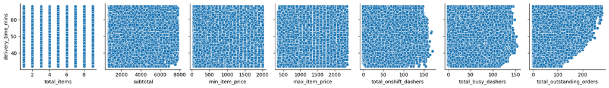

```python
sns.pairplot(
    df,
    x_vars=['total_items', 'subtotal', 'min_item_price', 'max_item_price', 'total_onshift_dashers', 'total_busy_dashers', 'total_outstanding_orders'],
    y_vars=['delivery_time_mins'],)
plt.show()
```

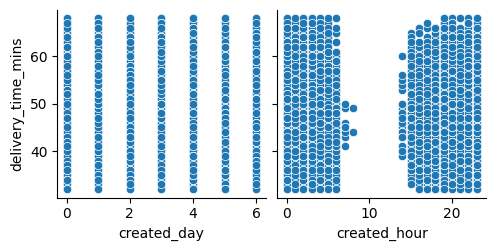

```python
sns.pairplot(
    df,
    x_vars=['created_day', 'created_hour'],
    y_vars=['delivery_time_mins'],)
plt.show()
```

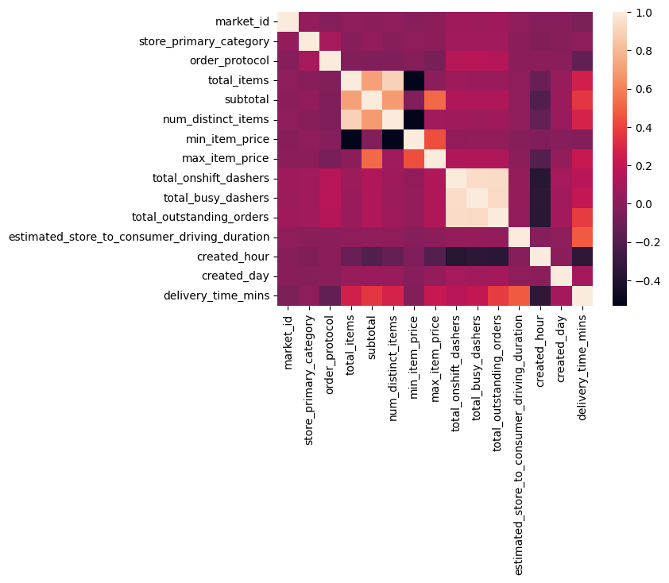

```python
sns.heatmap(df.corr())
plt.show()
```

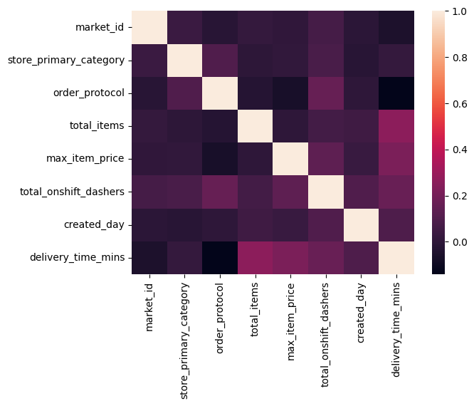

```python
sns.heatmap(df[['market_id', 'store_primary_category', 'order_protocol', 'total_items', 'max_item_price', 'total_onshift_dashers', 'created_day', 'delivery_time_mins']].corr())
plt.show()
```

## NN Modelling

#### Training a NN model

```python
df.head()
```

|  | market_id | store_primary_category | order_protocol | total_items | subtotal | num_distinct_items | min_item_price | max_item_price | total_onshift_dashers | total_busy_dashers | total_outstanding_orders | estimated_store_to_consumer_driving_duration | created_hour | created_day | delivery_time_mins |
| --- | --- | --- | --- | --- | --- | --- | --- | --- | --- | --- | --- | --- | --- | --- | --- |
| 0 | 1 | 4 | 1 | 4 | 3441 | 4 | 557 | 1239 | 33 | 14 | 21 | 861 | 22 | 4 | 47.0 |
| 1 | 2 | 45 | 2 | 1 | 1900 | 1 | 1400 | 1400 | 1 | 2 | 2 | 690 | 21 | 1 | 44.0 |
| 2 | 2 | 35 | 3 | 4 | 4771 | 3 | 820 | 1604 | 8 | 6 | 18 | 289 | 0 | 0 | 55.0 |
| 3 | 1 | 37 | 1 | 1 | 1525 | 1 | 1525 | 1525 | 5 | 6 | 8 | 795 | 3 | 3 | 59.0 |
| 4 | 1 | 37 | 1 | 2 | 3620 | 2 | 1425 | 2195 | 5 | 5 | 7 | 205 | 2 | 1 | 46.0 |

```python
# Dropping 'store primary category' and 'order protocol' from feature list

df_reduced = df.drop(['store_primary_category', 'order_protocol'], axis=1)
```

```python
# Example to demonstrate categorical encoding
def encode_categorical_data(dataframe):
    # Assume some features are categorical
    categorical_columns = ['market_id']

    # Apply One-Hot Encoding
    one_hot_encoder = OneHotEncoder(sparse_output=False, drop='first')  # Drop first to avoid multicollinearity
    encoded_features = pd.DataFrame(
        one_hot_encoder.fit_transform(dataframe[categorical_columns]),
        columns=one_hot_encoder.get_feature_names_out(categorical_columns)
    )

    # Drop original categorical columns and concatenate encoded columns
    dataframe = dataframe.drop(categorical_columns, axis=1)
    dataframe = pd.concat([dataframe.reset_index(drop=True), encoded_features.reset_index(drop=True)], axis=1)
    return dataframe
```

```python
# Encode categorical data
df_reduced_encoded = encode_categorical_data(df_reduced)
```

```python
df_reduced_encoded.head()
```

|  | total_items | subtotal | num_distinct_items | min_item_price | max_item_price | total_onshift_dashers | total_busy_dashers | total_outstanding_orders | estimated_store_to_consumer_driving_duration | created_hour | created_day | delivery_time_mins | market_id_2 | market_id_3 | market_id_4 | market_id_5 | market_id_6 |
| --- | --- | --- | --- | --- | --- | --- | --- | --- | --- | --- | --- | --- | --- | --- | --- | --- | --- |
| 0 | 4 | 3441 | 4 | 557 | 1239 | 33 | 14 | 21 | 861 | 22 | 4 | 47.0 | 0.0 | 0.0 | 0.0 | 0.0 | 0.0 |
| 1 | 1 | 1900 | 1 | 1400 | 1400 | 1 | 2 | 2 | 690 | 21 | 1 | 44.0 | 1.0 | 0.0 | 0.0 | 0.0 | 0.0 |
| 2 | 4 | 4771 | 3 | 820 | 1604 | 8 | 6 | 18 | 289 | 0 | 0 | 55.0 | 1.0 | 0.0 | 0.0 | 0.0 | 0.0 |
| 3 | 1 | 1525 | 1 | 1525 | 1525 | 5 | 6 | 8 | 795 | 3 | 3 | 59.0 | 0.0 | 0.0 | 0.0 | 0.0 | 0.0 |
| 4 | 2 | 3620 | 2 | 1425 | 2195 | 5 | 5 | 7 | 205 | 2 | 1 | 46.0 | 0.0 | 0.0 | 0.0 | 0.0 | 0.0 |

### Split and Scale the data

```python
# Split data into features and target
y = df_reduced_encoded['delivery_time_mins']
X = df_reduced_encoded.drop('delivery_time_mins', axis=1)

# Split into train and test
X_train, X_test, y_train, y_test = train_test_split(X, y, test_size=0.2, random_state=42)

# Scale features
scaler = MinMaxScaler()
X_train_scaled = scaler.fit_transform(X_train)
X_test_scaled = scaler.transform(X_test)
```

```python
from tensorflow.keras.callbacks import LearningRateScheduler
from keras.layers import LeakyReLU
from tensorflow.keras.losses import LogCosh, Huber
from tensorflow.keras.callbacks import Callback
import tensorflow as tf
from tensorflow.keras.losses import MeanSquaredError
```

## NN_Regression model:

Takes input features (X_train) and predicts a continuous numerical value (y_train) which is delivery time

```python
# Model definition function
def create_and_train_model(X_train, y_train, X_test, y_test, epochs=50):

    # Model definition
    def create_model(input_shape):
        model = Sequential([
            Dense(32, input_shape=(input_shape,), kernel_initializer='he_normal'),
            BatchNormalization(),
            LeakyReLU(alpha=0.01),
            Dense(64),
            BatchNormalization(),
            LeakyReLU(alpha=0.01),
            Dense(128),
            BatchNormalization(),
            LeakyReLU(alpha=0.01),
            Dense(64),
            BatchNormalization(),
            LeakyReLU(alpha=0.01),
            Dense(1, activation='linear')
        ])

        model.compile(optimizer=Adam(learning_rate=0.001, global_clipnorm=1.0), loss='mse', metrics=['mae'])
        return model

    class GradientLogger(Callback):
        def __init__(self, train_data):
            super().__init__()
            self.train_data = train_data  # Training data as (X, y)

        def on_epoch_end(self, epoch, logs=None):
            # Get the training data
            X, y = self.train_data
            with tf.GradientTape() as tape:
                # Forward pass
                y_pred = self.model(X, training=True)  # Access self.model directly
                # Compute the loss
                loss = self.model.compiled_loss(y, y_pred)

            # Compute gradients
            gradients = tape.gradient(loss, self.model.trainable_variables)

            # Log gradient statistics
            grad_norms = [tf.norm(g).numpy() for g in gradients if g is not None]
            print(f"\nEpoch {epoch + 1}: Gradient Norms:")
            print(f"  Mean: {np.mean(grad_norms):.4f}")
            print(f"  Min: {np.min(grad_norms):.4f}")
            print(f"  Max: {np.max(grad_norms):.4f}")

    X_train_sample, y_train_sample = X_train[:100], y_train[:100]
    gradient_logger = GradientLogger(train_data=(X_train_sample, y_train_sample))

    # Create and train the model
    input_shape = X_train.shape[1]
    model = create_model(input_shape)
    history = model.fit(X_train, y_train, epochs=epochs, verbose=1, validation_split=0.1, batch_size=512, callbacks=[gradient_logger])

    # Predictions and final MSE calculation
    predictions = model.predict(X_test)
    mse = mean_squared_error(y_test, predictions)

     # Plot training and validation loss
    plt.figure(figsize=(10, 4))
    plt.plot(history.history['loss'], label='Training Loss', color='blue')
    plt.plot(history.history['val_loss'], label='Validation Loss', color='orange')
    plt.xlabel('Epochs')
    plt.ylabel('Loss (MSE)')
    plt.title('Training and Validation Loss Across Epochs')
    plt.legend()
    plt.grid(True)
    plt.show()

    return mse
```

```
213/216 ━━━━━━━━━━━━━━━━━━━━ 0s 7ms/step - loss: 1709.9170 - mae: 40.7079
Epoch 1: Gradient Norms:
  Mean: 42.5064
  Min: 0.0000
  Max: 351.9182
216/216 ━━━━━━━━━━━━━━━━━━━━ 7s 9ms/step - loss: 1705.6023 - mae: 40.6541 - val_loss: 1486.1652 - val_mae: 37.9750
  6/216 ━━━━━━━━━━━━━━━━━━━━ 2s 10ms/step - loss: 1296.0355 - mae: 35.5363
```

```
213/216 ━━━━━━━━━━━━━━━━━━━━ 0s 9ms/step - loss: 885.1050 - mae: 29.0658
Epoch 2: Gradient Norms:
  Mean: 45.6871
  Min: 0.0000
  Max: 301.2062
216/216 ━━━━━━━━━━━━━━━━━━━━ 2s 10ms/step - loss: 880.8814 - mae: 28.9873 - val_loss: 583.4118 - val_mae: 23.8286
213/216 ━━━━━━━━━━━━━━━━━━━━ 0s 7ms/step - loss: 186.4107 - mae: 12.0821
Epoch 3: Gradient Norms:
  Mean: 26.9279
  Min: 0.0000
  Max: 100.0658
216/216 ━━━━━━━━━━━━━━━━━━━━ 2s 9ms/step - loss: 184.6077 - mae: 11.9864 - val_loss: 51.5025 - val_mae: 6.5871
215/216 ━━━━━━━━━━━━━━━━━━━━ 0s 7ms/step - loss: 5.3718 - mae: 1.8213
Epoch 4: Gradient Norms:
  Mean: 17.5553
  Min: 0.0000
  Max: 60.8930
216/216 ━━━━━━━━━━━━━━━━━━━━ 2s 8ms/step - loss: 5.3701 - mae: 1.8211 - val_loss: 18.3685 - val_mae: 3.7917
214/216 ━━━━━━━━━━━━━━━━━━━━ 0s 8ms/step - loss: 3.2691 - mae: 1.4306
Epoch 5: Gradient Norms:
  Mean: 10.5439
  Min: 0.0000
  Max: 37.6597
216/216 ━━━━━━━━━━━━━━━━━━━━ 3s 10ms/step - loss: 3.2675 - mae: 1.4304 - val_loss: 4.0363 - val_mae: 1.6171
213/216 ━━━━━━━━━━━━━━━━━━━━ 0s 8ms/step - loss: 2.7688 - mae: 1.3140
Epoch 6: Gradient Norms:
  Mean: 14.8548
  Min: 0.0000
  Max: 51.3239
216/216 ━━━━━━━━━━━━━━━━━━━━ 2s 9ms/step - loss: 2.7718 - mae: 1.3148 - val_loss: 3.4180 - val_mae: 1.5370
209/216 ━━━━━━━━━━━━━━━━━━━━ 0s 7ms/step - loss: 2.6224 - mae: 1.2822
Epoch 7: Gradient Norms:
  Mean: 14.9851
  Min: 0.0000
  Max: 52.6832
216/216 ━━━━━━━━━━━━━━━━━━━━ 2s 8ms/step - loss: 2.6196 - mae: 1.2808 - val_loss: 3.0214 - val_mae: 1.3502
214/216 ━━━━━━━━━━━━━━━━━━━━ 0s 7ms/step - loss: 2.4941 - mae: 1.2469
Epoch 8: Gradient Norms:
  Mean: 13.9484
  Min: 0.0000
```

[output cut: 240 more lines]

```
  Max: 29.6540
216/216 ━━━━━━━━━━━━━━━━━━━━ 2s 11ms/step - loss: 1.8051 - mae: 1.0528 - val_loss: 1.6037 - val_mae: 0.9797
211/216 ━━━━━━━━━━━━━━━━━━━━ 0s 9ms/step - loss: 1.8287 - mae: 1.0600
Epoch 49: Gradient Norms:
  Mean: 7.0180
  Min: 0.0000
  Max: 28.3437
216/216 ━━━━━━━━━━━━━━━━━━━━ 2s 10ms/step - loss: 1.8307 - mae: 1.0612 - val_loss: 1.7347 - val_mae: 1.0677
211/216 ━━━━━━━━━━━━━━━━━━━━ 0s 9ms/step - loss: 1.8228 - mae: 1.0594
Epoch 50: Gradient Norms:
  Mean: 6.8097
  Min: 0.0000
  Max: 30.3872
216/216 ━━━━━━━━━━━━━━━━━━━━ 2s 10ms/step - loss: 1.8272 - mae: 1.0604 - val_loss: 1.5262 - val_mae: 0.9706
957/957 ━━━━━━━━━━━━━━━━━━━━ 3s 2ms/step
```

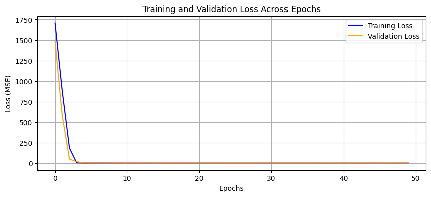

```python
# Train model with all features
mse_all_features = create_and_train_model(X_train_scaled, y_train, X_test_scaled, y_test)
```

```python
mse_all_features
```

```
np.float64(1.5409664325660857)
```

- The training and validation errors remained relatively close, so there was no strong evidence of severe overfitting in the final training run. Training Validation MSE 1.8272 1.5262 MAE 1.0604 0.9706 - For epoch 50: Mean = 6.8097 Min = 0.0000 Max = 30.3872 which means Gradients aren't exploding throughout training. - The NN_regression model achieved a validation MSE of 1.5262 and MAE of 0.9706, indicating an average prediction error of approximately 0.97 units of delivery time.